# Experimental Design: Introduction

Last updated: 2017-04-19

## Types of errors and statistical power

|  | Reject H<sub>0</sub> | Fail to reject H<sub>0</sub> |
| --- | --- | --- |
| H<sub>0</sub> is true | Type I error | *Correct* |
| H<sub>0</sub> is false | *Correct* | Type II error |

Type I error occurs when:

- *P* is small by *random chance*, given that \(\alpha\) is chosen ahead of the test

Type II error probability depends on:

- The value of \(\alpha\)
- How "wrong" H<sub>0</sub> is

## Power

- Probability that a random sample will lead to a rejection of H<sub>0</sub>
- Dependent on how different the truth is from the null hypothesis
- Inversely related to type II errors
  - High power \(\rightarrow\) low type II errors
  - Low power \(\rightarrow\) high type II errors

## Power depends on effect size

*Effect size*: The magnitude of the deviation from H<sub>0</sub>.

If we can estimate effect size *before we do the study*, we can estimate the power.

- Use previous information
  - Your own pilot studies
  - Other similar studies
- Determine how big a difference we want to be able to detect
  - A difference less than *X* is not biologically meaningful

## Effect size

> "An effect size is a standardized measure that quantifies the size of the difference between two groups or the strength of an association between two variables." (Button et al. 2013)

Measures of effect size:

1. Pearson's *r*
2. *R*<sup>2</sup>: but note caveats of *R*<sup>2</sup>
3. Cohen's *d*: *t*-tests (Cohen 1960)
4. Cohen's \(f^2\), \(\eta^2\): ANOVA-like (Olejnik and Algina 2003)
5. Odds ratio (logistic regression)

## Importance of effect size

> "For example, if a sample size is 10 000, a significant *P* value is likely to be found even when the difference in outcomes between groups is negligible and may not justify an expensive or time-consuming intervention over another." (Sullivan and Feinn 2012)

Consider an ordinary *t*-test:

\[t=\frac{\bar{Y}_{1}-\bar{Y}_{2}}{SE_{Y_{1}-Y_{2}}}\]

## Example calculation of effect size

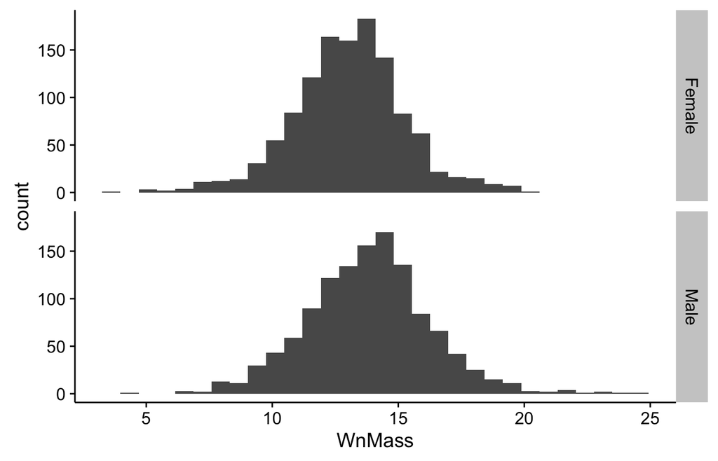

## Cohen's *d*

Standardized differences measured in standard deviations.

General guide for *t*-tests (also see Sullivan and Feinn 2012):

- 0.2 = "Small"
- 0.5 = "Medium"
- 0.8 = "Large"

What you do with "small", "medium", and "large" is up to you.

## According to Cohen

> "there is a certain risk inherent in offering conventional operational definitions for those terms for use in power analysis in as diverse a field of inquiry as behavioral science"

## Cohen's *d* using the `DescTools` package

\[ d = \frac{\bar{Y_F} - \bar{Y_M}}{s_{\mbox{pooled}}} \]

```r
library(DescTools)
Females <- M_subs$WnMass[M_subs$Sex == "Female"]
Males <- M_subs$WnMass[M_subs$Sex == "Male"]
CohenD(Females, Males)
```

```
## [1] -0.3417314
## attr(,"magnitude")
## [1] "small"
```

## \(\eta^2\) for jet lag data with `EtaSq()`

Also in `DescTools`:

```r
data("JetLagKnees", package = "abd")
fm <- lm(shift ~ treatment, data = JetLagKnees)
EtaSq(fm)
```

```
##              eta.sq eta.sq.part
## treatment 0.4341684   0.4341684
```

## Power analysis is used for planning

1. What sample size do I need?
2. What is my power?
3. How large of a difference can I detect?

How much power is enough power? Some say 0.8.

## Post-analysis power calculations

Hoenig and Heisey (2001):

> "There is a large literature advicating that power calculation be made whenever one performs a statistical test of a hypothesis and one obtains a statitically nonsignificant result. … This approach, which appears in various forms, is fundamentally flawed."
- "Observed power" (power of an observed *P* value from a post-hoc power analysis) is mathematically tied to the *P* value.

## Power analysis in R

1. `pwr` package
   - `pwr.t.test()`
   - `pwr.anova.test()`
   - `pwr.r.test()`
2. Do it yourself (some examples later with Monte Carlo methods)

## Commonalities

1. *n* samples (*k* groups)
2. *d* or *f* for hypothesized effect size (*r* hypothesized correlation)
3. \(\alpha\) level
4. Power

```r
library(pwr)
cohen.ES(test = "anov", size = "medium")
```

```
##
##      Conventional effect size from Cohen (1982)
##
##            test = anov
##            size = medium
##     effect.size = 0.25
```

## Power analysis for a *t*-test

Possible questions:

1. What sample size do I need for a given effect size, \(\alpha\), and power?
2. What will my power be, for a given effect size, \(\alpha\), and sample?
3. What effect size will I be able to detect for a given sample, power, and \(\alpha\)? (This is difficult, because how do you know power?)

## What sample size?

```r
pwr.t.test(d = 0.5, sig.level = 0.05, power = 0.80,
           type = "two.sample")
```

```
##
##      Two-sample t test power calculation
##
##               n = 63.76561
##               d = 0.5
##       sig.level = 0.05
##           power = 0.8
##     alternative = two.sided
##
## NOTE: n is number in *each* group
```

## What is my power?

```r
pwr.t.test(d = 0.5, sig.level = 0.05, n = 15,
           type = "two.sample")
```

```
##
##      Two-sample t test power calculation
##
##               n = 15
##               d = 0.5
##       sig.level = 0.05
##           power = 0.262443
##     alternative = two.sided
##
## NOTE: n is number in *each* group
```

## What effect size can I detect?

```r
pwr.t.test(power = 0.80, sig.level = 0.05, n = 1227,
           type = "two.sample")
```

```
##
##      Two-sample t test power calculation
##
##               n = 1227
##               d = 0.113158
##       sig.level = 0.05
##           power = 0.8
##     alternative = two.sided
##
## NOTE: n is number in *each* group
```

## Quiz 14-2

Lecture 14-3

## References

Button, K. S., J. P. A. Ioannidis, C. Mokrysz, B. A. Nosek, J. Flint, E. S. J. Robinson, and M. R. Munafò. 2013. Power Failure: Why Small Sample Size Undermines the Reliability of Neuroscience. *Nature reviews. Neuroscience* 14:365–376.

Cohen, J. 1960. A Coefficient of Agreement for Nominal Scales. *Educational and psychological measurement* 20:37–46.

Hoenig, J. M., and D. M. Heisey. 2001. The Abuse of Power: The Pervasive Fallacy of Power Calculations for Data Analysis. *The American statistician* 55:19–24. [American Statistical Association, Taylor & Francis, Ltd.].

Olejnik, S., and J. Algina. 2003. Generalized Eta and Omega Squared Statistics: Measures of Effect Size for Some Common Research Designs. *Psychological methods* 8:434–447.

Sullivan, G. M., and R. Feinn. 2012. Using Effect Size—or Why the *P* Value Is Not Enough. *Journal of graduate medical education* 4:279–282.